```python
import pandas as pd
import os
from sklearn.preprocessing import OneHotEncoder
import matplotlib.pyplot as plt
import numpy as np

# Import credit data

df=pd.read_csv('../../Downloads/credit_data.csv')
```

# Exploratory Data Analysis

Lets see what is the behavior of each variable. As a first approach it is useful to look the averages of the column 30 by the values of the column. Then we will see the most important variables with other methods.

```python
def plotMeansAndQs(dataFrame=df, columnName='1', targetColumn='30'):
    """
    Plots the means of the target column by value of column
        dataFrame: pandas DataFrame containing the data
        targetColumn: String containing the target column name
        columnName: String containing the column name
    """

    fig, ax = plt.subplots(figsize=(20,8))

    uniqueValues=dataFrame[columnName].unique().tolist()

    if dataFrame[columnName].dtype=='int64':
        uniqueValues.sort()

    ax.text(-2, -.1, 'Count')
    for i, value in zip(range(0,len(uniqueValues)), uniqueValues):
        filteredDataFrame=dataFrame[dataFrame[columnName]==value][targetColumn]
        meanTargetValue=filteredDataFrame.mean()
        ax.bar(i, meanTargetValue, color=plt.cm.Reds(meanTargetValue))
        ax.text(i-.1, -.1, filteredDataFrame.count())


    plt.xticks(ticks=np.arange(i+1), labels=uniqueValues)
    ax.spines['top'].set_visible(False)
    ax.spines['right'].set_visible(False)
    ax.spines['left'].set_visible(False)
    ax.set_title(f"Column {targetColumn} means by column {columnName} values")
    return
```

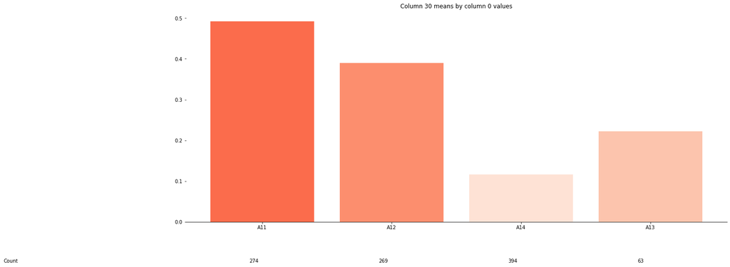

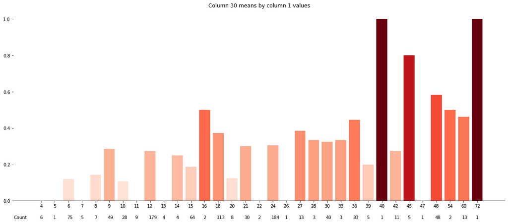

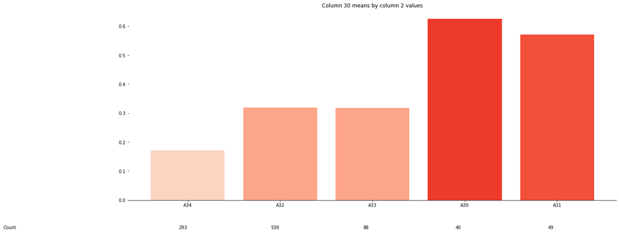

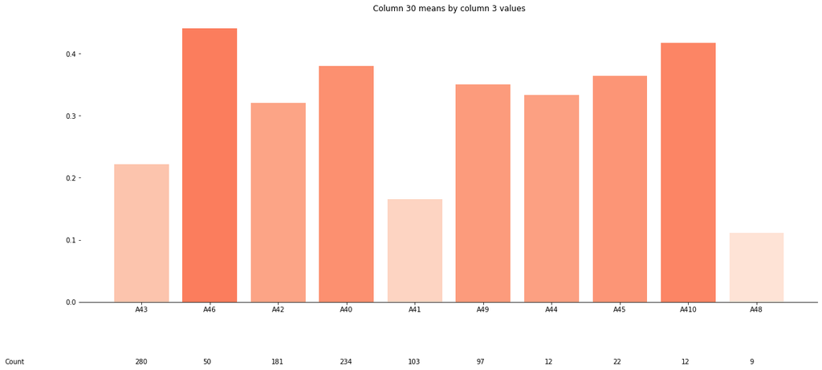

[figure not shown]

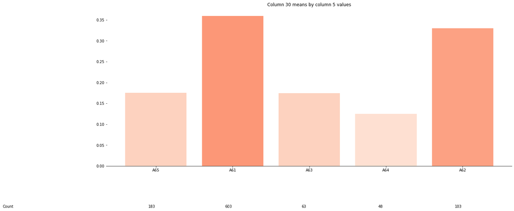

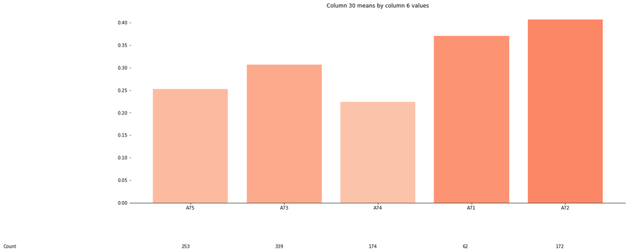

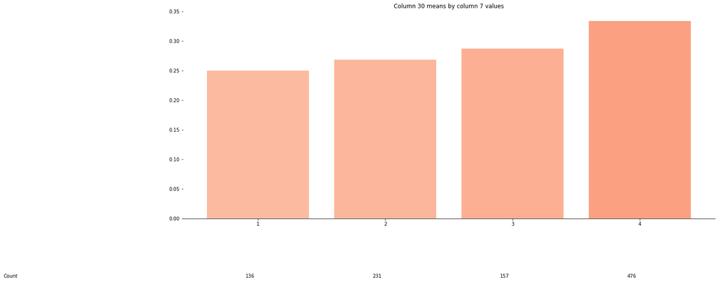

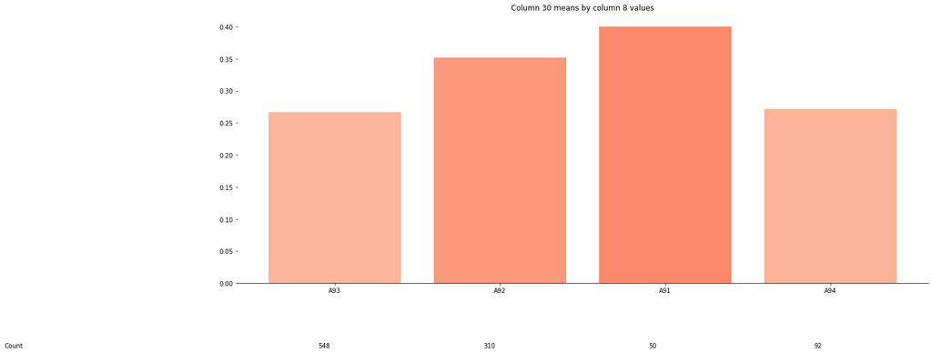

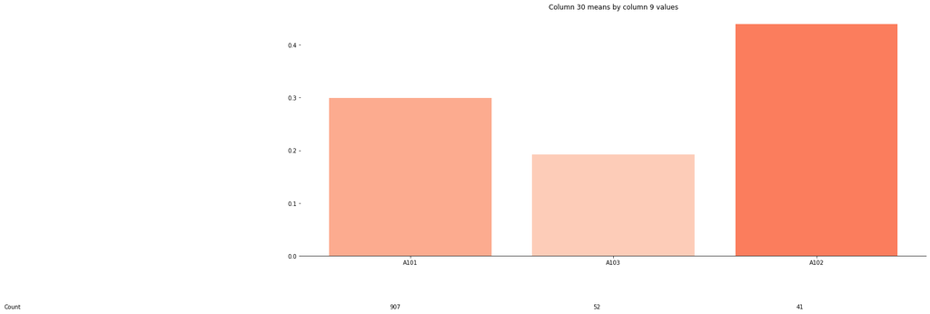

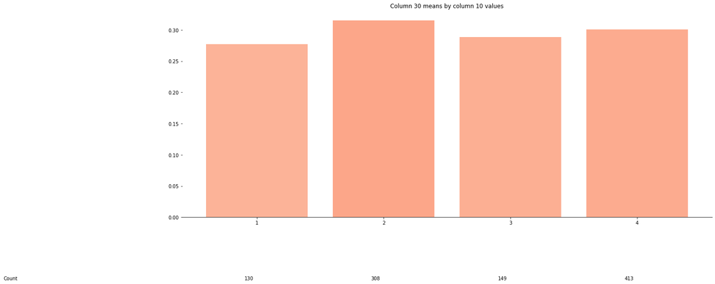

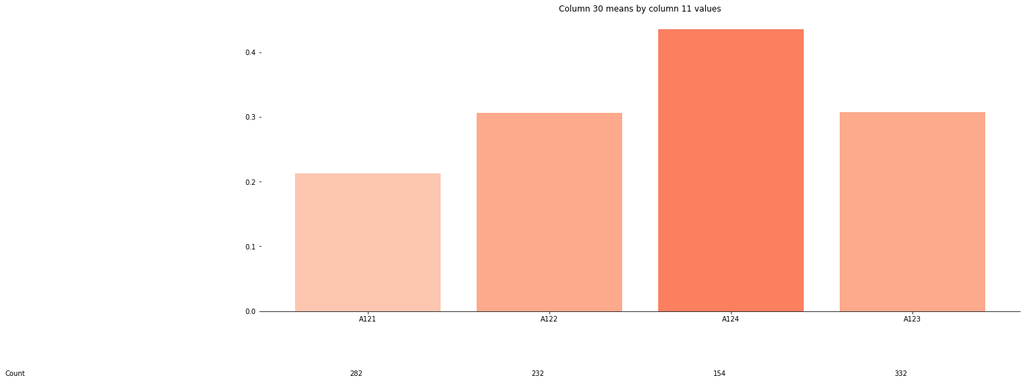

[19 more figures not shown]

```python
for column in df.columns:
    plotMeansAndQs(columnName=column)
```

## Observations

Thanks to the previous plots we can already have an idea of the effects of each variable

- [x] Column 0 A11 and A12 categories have higher default rates than the others
- [x] Column 1 seems to have a positive effect in the credit default
- [x] Column 2 A30 and A31 categories have higher default rates than others, but low Q
- [x] Column 3 A43, A41 and A48 have lower rates than the other categories
- [x] Column 5 A61 and A62 have higher rate than other categories
- [x] Column 7 has a positive tendency, but the increase rate is low
- [x] Column 8 A92 and A91 have higher rates
- [x] Column 9 A102 has higher rate
- [x] Column 11 A124 has higher rate
- [x] Column 14 A152 has lower rate
- [x] Column 19 A201 has higher rate
- [x] Column 21 seems to have a positive effect in the credit default
- [x] Column 27 seems to have a slightly positive effect in the credit default

## Correlation between variables

It is important to know what variables are correlated because it could be redundant to consider highly correlated variables in a model

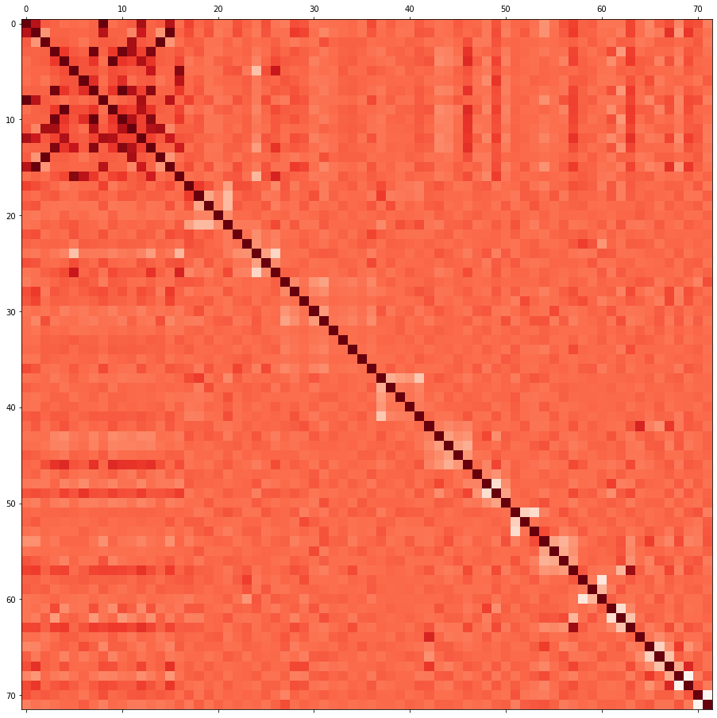

```python
# Generate dummies columns

db=pd.get_dummies(df)

# Correlation matrix

fig, ax =plt.subplots(figsize=(16,16))

ax.matshow(db.corr(), cmap=plt.cm.Reds)
plt.show()
```

It seems that the correlation is more frequent in the first 20 columns

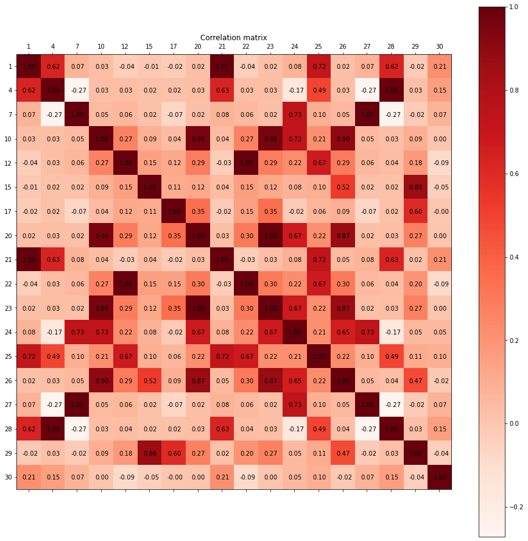

```python
fig, ax =plt.subplots(figsize=(16,16))

lastColumnIndex=18
corr_matrix=db.corr().iloc[0:lastColumnIndex, 0:lastColumnIndex]
cx=ax.matshow(corr_matrix, cmap=plt.cm.Reds)
ax.set_title("Correlation matrix")
fig.colorbar(cx)
plt.xticks(ticks=np.arange(lastColumnIndex), labels=corr_matrix.columns)
plt.yticks(ticks=np.arange(lastColumnIndex), labels=corr_matrix.columns)

listIteration=np.arange(lastColumnIndex)
for i in listIteration:
    for j in listIteration:
        ax.text(i-.25, j+.1, '{:.2f}'.format(corr_matrix.iloc[i,j]))


plt.show()
```

### Correlated variables

- [x] Columns 1 and 21, 4 and 28, 7 and 27, 10 and 23, 10 and 20, 12 and 22, 20 and 23 have a correlation near to 1
- [x] Columns 26 and 10, 29 and 15, 26 and 20, 26 and 23 have a correlation near to 0.9
- [x] Columns 25 and 1, 24 and 7, 24 and 10, 25 and 12, 24 and 20, 21 and 25, 22 and 25, 24 and 27 have a correlation near to 0.7

```python
toDrop=corr_matrix[corr_matrix >= 0.95]
```

```python
toDrop
```

|  | 1 | 4 | 7 | 10 | 12 | 15 | 17 | 20 | 21 | 22 | 23 | 24 | 25 | 26 | 27 | 28 | 29 | 30 |
| --- | --- | --- | --- | --- | --- | --- | --- | --- | --- | --- | --- | --- | --- | --- | --- | --- | --- | --- |
| 1 | 1.000000 | NaN | NaN | NaN | NaN | NaN | NaN | NaN | 0.998854 | NaN | NaN | NaN | NaN | NaN | NaN | NaN | NaN | NaN |
| 4 | NaN | 1.000000 | NaN | NaN | NaN | NaN | NaN | NaN | NaN | NaN | NaN | NaN | NaN | NaN | NaN | 0.999992 | NaN | NaN |
| 7 | NaN | NaN | 1.0 | NaN | NaN | NaN | NaN | NaN | NaN | NaN | NaN | NaN | NaN | NaN | 1.0 | NaN | NaN | NaN |
| 10 | NaN | NaN | NaN | 1.000000 | NaN | NaN | NaN | 0.951525 | NaN | NaN | 0.951525 | NaN | NaN | NaN | NaN | NaN | NaN | NaN |
| 12 | NaN | NaN | NaN | NaN | 1.000000 | NaN | NaN | NaN | NaN | 0.999505 | NaN | NaN | NaN | NaN | NaN | NaN | NaN | NaN |
| 15 | NaN | NaN | NaN | NaN | NaN | 1.0 | NaN | NaN | NaN | NaN | NaN | NaN | NaN | NaN | NaN | NaN | NaN | NaN |
| 17 | NaN | NaN | NaN | NaN | NaN | NaN | 1.0 | NaN | NaN | NaN | NaN | NaN | NaN | NaN | NaN | NaN | NaN | NaN |
| 20 | NaN | NaN | NaN | 0.951525 | NaN | NaN | NaN | 1.000000 | NaN | NaN | 1.000000 | NaN | NaN | NaN | NaN | NaN | NaN | NaN |
| 21 | 0.998854 | NaN | NaN | NaN | NaN | NaN | NaN | NaN | 1.000000 | NaN | NaN | NaN | NaN | NaN | NaN | NaN | NaN | NaN |
| 22 | NaN | NaN | NaN | NaN | 0.999505 | NaN | NaN | NaN | NaN | 1.000000 | NaN | NaN | NaN | NaN | NaN | NaN | NaN | NaN |
| 23 | NaN | NaN | NaN | 0.951525 | NaN | NaN | NaN | 1.000000 | NaN | NaN | 1.000000 | NaN | NaN | NaN | NaN | NaN | NaN | NaN |
| 24 | NaN | NaN | NaN | NaN | NaN | NaN | NaN | NaN | NaN | NaN | NaN | 1.0 | NaN | NaN | NaN | NaN | NaN | NaN |
| 25 | NaN | NaN | NaN | NaN | NaN | NaN | NaN | NaN | NaN | NaN | NaN | NaN | 1.0 | NaN | NaN | NaN | NaN | NaN |
| 26 | NaN | NaN | NaN | NaN | NaN | NaN | NaN | NaN | NaN | NaN | NaN | NaN | NaN | 1.0 | NaN | NaN | NaN | NaN |
| 27 | NaN | NaN | 1.0 | NaN | NaN | NaN | NaN | NaN | NaN | NaN | NaN | NaN | NaN | NaN | 1.0 | NaN | NaN | NaN |
| 28 | NaN | 0.999992 | NaN | NaN | NaN | NaN | NaN | NaN | NaN | NaN | NaN | NaN | NaN | NaN | NaN | 1.000000 | NaN | NaN |
| 29 | NaN | NaN | NaN | NaN | NaN | NaN | NaN | NaN | NaN | NaN | NaN | NaN | NaN | NaN | NaN | NaN | 1.0 | NaN |
| 30 | NaN | NaN | NaN | NaN | NaN | NaN | NaN | NaN | NaN | NaN | NaN | NaN | NaN | NaN | NaN | NaN | NaN | 1.0 |

```python
columnsToDrop=['21','28','27','20','23','22']

db.drop(columns=columnsToDrop)
```

|  | 1 | 4 | 7 | 10 | 12 | 15 | 17 | 24 | 25 | 26 | ... | 14_A152 | 14_A153 | 16_A171 | 16_A172 | 16_A173 | 16_A174 | 18_A191 | 18_A192 | 19_A201 | 19_A202 |
| --- | --- | --- | --- | --- | --- | --- | --- | --- | --- | --- | --- | --- | --- | --- | --- | --- | --- | --- | --- | --- | --- |
| 0 | 6 | 1169 | 4 | 4 | 67 | 2 | 1 | 8 | 73 | 6 | ... | 1 | 0 | 0 | 0 | 1 | 0 | 0 | 1 | 1 | 0 |
| 1 | 48 | 5951 | 2 | 2 | 22 | 1 | 1 | 4 | 70 | 3 | ... | 1 | 0 | 0 | 0 | 1 | 0 | 1 | 0 | 1 | 0 |
| 2 | 12 | 2096 | 2 | 3 | 49 | 1 | 2 | 5 | 61 | 4 | ... | 1 | 0 | 0 | 1 | 0 | 0 | 1 | 0 | 1 | 0 |
| 3 | 42 | 7882 | 2 | 4 | 45 | 1 | 2 | 6 | 87 | 5 | ... | 0 | 1 | 0 | 0 | 1 | 0 | 1 | 0 | 1 | 0 |
| 4 | 24 | 4870 | 3 | 4 | 53 | 2 | 2 | 7 | 77 | 6 | ... | 0 | 1 | 0 | 0 | 1 | 0 | 1 | 0 | 1 | 0 |
| ... | ... | ... | ... | ... | ... | ... | ... | ... | ... | ... | ... | ... | ... | ... | ... | ... | ... | ... | ... | ... | ... |
| 995 | 12 | 1736 | 3 | 4 | 31 | 1 | 1 | 7 | 43 | 5 | ... | 1 | 0 | 0 | 1 | 0 | 0 | 1 | 0 | 1 | 0 |
| 996 | 30 | 3857 | 4 | 4 | 40 | 1 | 1 | 8 | 70 | 5 | ... | 1 | 0 | 0 | 0 | 0 | 1 | 0 | 1 | 1 | 0 |
| 997 | 12 | 804 | 4 | 4 | 38 | 1 | 1 | 8 | 50 | 5 | ... | 1 | 0 | 0 | 0 | 1 | 0 | 1 | 0 | 1 | 0 |
| 998 | 45 | 1845 | 4 | 4 | 23 | 1 | 1 | 8 | 68 | 5 | ... | 0 | 1 | 0 | 0 | 1 | 0 | 0 | 1 | 1 | 0 |
| 999 | 45 | 4576 | 3 | 4 | 27 | 1 | 1 | 7 | 72 | 5 | ... | 1 | 0 | 0 | 0 | 1 | 0 | 1 | 0 | 1 | 0 |

1000 rows × 66 columns

## Feature selection

[output not shown]

1000 rows × 72 columns

# Modeling

## Is it correct to use a regression for this kind of problems?

It is possible, but not the best model for classification problems. For modeling the risk of default is commonly used non linear models (logit, probit, classification trees) due that those models estimate the probability of doing something.